# Stat 324 Homework #1

Svadrut Kukunooru

*Submit your homework to Canvas by the due date and time. Email your lecturer if you have extenuating circumstances and need to request an extension.

*If an exercise asks you to use R, include a copy of the code and output. Please edit your code and output to be only the relevant portions.

*If a problem does not specify how to compute the answer, you many use any appropriate method. I may ask you to use R or use manual calculations on your exams, so practice accordingly.

*You must include an explanation and/or intermediate calculations for an exercise to be complete.

*Be sure to submit the HWK1 Autograde Quiz which will give you 20 of your 40 accuracy points.

*50 points total: 40 points accuracy, and 10 points completion

## Basics of Statistics and Summarizing Data Graphically (I)

**Exercise 1**. A number of individuals are interested in the proportion of citizens within a county who will vote to use tax money to upgrade a professional baseball stadium in the upcoming vote. Consider the following methods:

The **Baseball Team Owner** surveyed 8,000 people attending one of the baseball games held in the stadium. Seventy eight percent (78%) of respondents said they supported the use of tax money to upgrade the stadium.

The **Pollster** generated 1,000 random numbers between 1-52,661 (number of county voters in last election) and surveyed the 1,000 citizens who corresponded to those numbers on the voting roll. Forty three percent (43%) of respondents said they supported the use of tax money to upgrade the stadium.

> 1. What is the population of interest? What is the parameter of interest? Will this parameter ever be calculated?

The population of interest is the U.S. citizens and attendees of a baseball game held in the stadium. The parameter of interest is the proportion of citizens within a county will vote to use tax money to upgrade a professional baseball stadium in the upcoming vote.

> 2. What were the sample sizes used and statistics calculated from those samples? Are these simple random samples from the population of interest?

The sample size used was the 1,000 citizens randomly selected using a random number generator, as well as the 8,000 people attending a baseball game. The statistics calculated from these samples are the percentage of people who said they would support using tax money to upgrade the baseball stadium. The pollster method uses a simple random sample from the population of interest because they use a random number generator, but the baseball team owner uses people who attend a certain baseball game, which is not a simple random sample because the people in the sample are not equally likely to be picked.

> 3. The baseball team owner claims that the survey done at the baseball stadium will better predict the voting outcome because the sample size was much larger. What is your response?

The survey done at the baseball stadium will not better predict the voting outcome because the sample sise only consists of people who attend a baseball game, which may be biased because they may be bigger fans than the rest of the citizens of upgrading the stadium they attend.

**Exercise 2:** After manufacture, computer disks are tested for errors. The table below summarizes the number of errors detected on each of the 100 disks produced in a day.

| Number of Defects | Number of Disks |
| --- | --- |
| 0 | 42 |
| 1 | 30 |
| 2 | 16 |
| 3 | 7 |
| 4 | 5 |

> 1. Describe the type of data that is being recorded about the sample of 100 disks, being as specific as possible.

The data being recorded about the sample of 100 disks is the amount of defects on the disk.

> 2. Code for a frequency histogram showing the frequency for number of errors on the 100 disks is given below.

> > bi. Knit the document and confirm that the histogram displays in the knitted file.

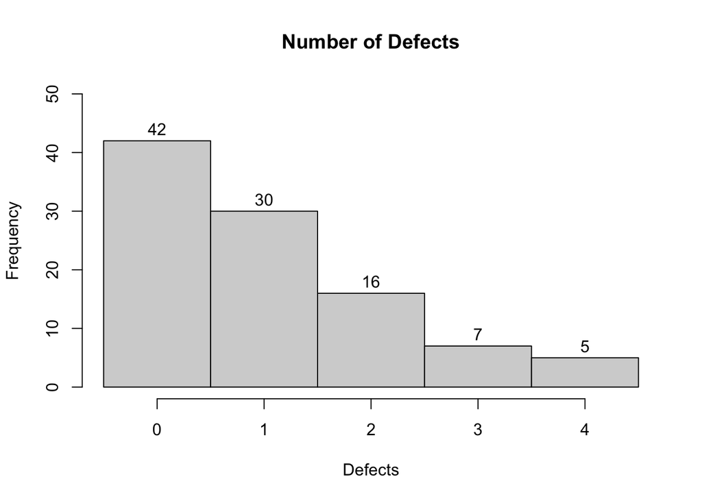

```r
error.data=c(rep(0,42), rep(1,30), rep(2,16), rep(3,7), rep(4, 5))
hist(error.data, breaks=c(seq(from=-0.5, 4.5, by=1)),
     xlab="Defects", main="Number of Defects",
     labels=TRUE, ylim=c(0,50))
```

> > bii. Describe what the rep() function does in this code chunk.

The rep() function creates vectors for each column in the histogram; e.g., the first `rep()`, `rep(0,42)` makes the column for the amount of disks that had zero defects, 42.

> > biii. Describe how this breaks command affects the histogram’s appearance in this code chunk. How would the histogram look different if the breaks() command was not included?

The histogram would look different in that it would use ranges rather than discrete numbers. It would be split into ranges like 0-1, 1-2, 2-3, etc.

> > biv. Describe how setting ylim=c(0,30) instead of ylim=c(0,50) would change the histogram’s appearance. Which value for ylim is perferable for clear communication of the data?

Setting `ylim=c(0,30)` would limit the y-axis to a maximum of 30. 50 would be a preferable value for clear communication of the data.